# hw

SA24204136 S Liu

2024-12-04

# Homework 0

Use knitr to produce at least 3 examples. For each example,texts should mix with figures and/or tables. Better to have mathematical formulas.

# Answer

# Homework 1

Exercises 3.4, 3.11, and 3.20 (pages 94-96,Statistical Computating with R)

# Answer

## 3.4

**Question:**The Rayleigh density is
$$f(x)=
\frac{x}{\sigma^2}e^{-\frac{x^2}{2\sigma^2}}$$
Develop an algorithm to generate random samples from a Rayleigh($\sigma$) distribution. Generate Rayleigh($\sigma$) samples for several choices of $\sigma$ > 0 and check that the mode of the generated samples is close to the theoretical mode $\sigma$ (check the histogram).

**Answer:**After observing the density function of Rayleigh,We can find that the root mean square of two independent Gaussian random variables is a Rayleigh distribution random variable. The joint density function of two independent Gaussian random variables is:
$$f_{XY}(x,y)=\frac{1}{2\pi\sigma^2}exp{-\frac{x^2+y^2}{2\sigma^2}}$$
Let $x=rcos\theta$,$y=rsin\theta$,and r is Rayleigh variable,we can get:
$$f(x)=
\frac{x}{\sigma^2}e^{-\frac{x^2}{2\sigma^2}}$$
So we can use two independent Gaussian random variables to generate Rayleigh variable.

when $\sigma$=1:

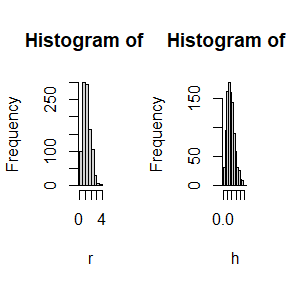

```r
set.seed(12345)
n<-1000
sigma<-1 #set the value of sigma
x<-rnorm(n,sd=sigma)
y<-rnorm(n,sd=sigma)
r<-sqrt(x^2+y^2)
h<-rweibull(n,shape=2)
par(mfrow=c(1,2))
hist(r) #algorithm to generate random samples
hist(h) #Rayleigh distribution
```

when $\sigma$=2:

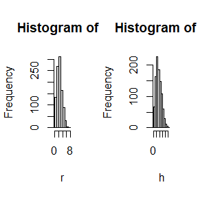

```r
sigma<-2 #set the value of sigma
x<-rnorm(n,sd=sigma)
y<-rnorm(n,sd=sigma)
r<-sqrt(x^2+y^2)
h<-rweibull(n,shape=2,scale=2)
par(mfrow=c(1,2))
hist(r) #algorithm to generate random samples
hist(h) #Rayleigh distribution
```

when $\sigma$=3:

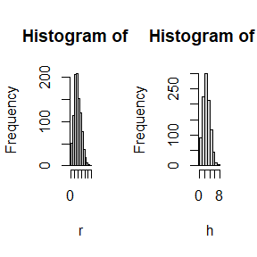

```r
sigma<-3 #set the value of sigma
x<-rnorm(n,sd=sigma)
y<-rnorm(n,sd=sigma)
r<-sqrt(x^2+y^2)
h<-rweibull(n,shape=2,scale=3)
par(mfrow=c(1,2))
hist(r) #algorithm to generate random samples
hist(h) #Rayleigh distribution
```

## 3.11

**Question:**Generate a random sample of size 1000 from a normal location mixture.The components of the mixture have N(0,1) and N(3,1) distributions with mixing probabilities $p_1$ and $p_2=1-p_1$.Graph the histogram of the sample with density superimposed,for $p_1=0.75$.Repeat with different values for $p_1$ and observe whether the empirical distribution of the mixture appears to be bimodal.Make a conjecture about the values of $p_1$ that produce bimodal mixtures.

**Answer:**

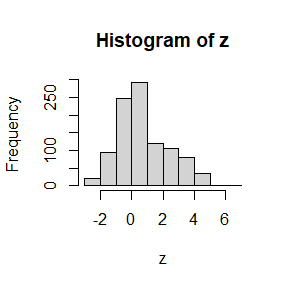

```r
set.seed(12345)
n=1000
p1=0.75
p2=1-p1
x=rnorm(n)
y=rnorm(n,mean=3)
r=sample(c(0,1),n,replace=TRUE,prob=c(p2,p1))
z=r*x+(1-r)*y
hist(z)
```

when $p_1=0.75$,the empirical distribution of the mixture don’t appears to be bimodal

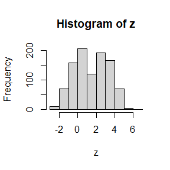

```r
p1=0.5
p2=1-p1
r=sample(c(0,1),n,replace=TRUE,prob=c(p2,p1))
z=r*x+(1-r)*y
hist(z)
```

when $p_1=0.5$,the empirical distribution of the mixture appears to be bimodal

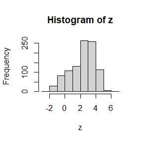

```r
p1=0.25
p2=1-p1
r=sample(c(0,1),n,replace=TRUE,prob=c(p2,p1))
z=r*x+(1-r)*y
hist(z)
```

when $p_1=0.25$,the empirical distribution of the mixture don’t appears to be bimodal

We can guess that when $p1$ is near to 0.5,the mixture appears to be bimodal.

## 3.20

**Question:**A compound Poisson process is a stochastic process{$X(t),t\geq0$} that can be represented as the random sum$X(t)=\sum_{i=1}^{N(t)}Y_i,t\geq0$,where{$X(t),t\geq0$}is a Poisson process and $Y_1$,$Y_2$,…are iid and independent of{$X(t),t\geq0$}.Write a program to simulate a compound Poisson($\lambda$)-Gamma process(Y has a Gamma distribution).Estimate the mean and the variance of X(10) for several choices of the parameters and compare with the theoretical values.Hint:Show that $E[X(t)]=\lambda tE[Y_1]$ and $Var(X(t))=\lambda tE[y_1^2]$.

**Answer:**

when r=1,$\beta=1$

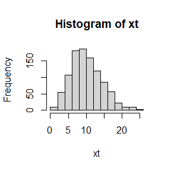

```r
r=1
beta=1
n=1000
t=10
nt=rpois(n,t)
xt=numeric(n)
i=j=0
for(i in 1:n){
  for(j in 1:nt[i]){
    xt[i]=xt[i]+rgamma(1,r,beta)
  }
}
hist(xt)
```

```r
m1=mean(xt)
v1=var(xt)
cat("the estimation of mean is ",m1,",the variance is ",v1,".the theoretical value of mean is 10,the variance is 20.")
```

```
## the estimation of mean is  10.04144 ,the variance is  18.70217 .the theoretical value of mean is 10,the variance is 20.
```

when r=2,$\beta=2$

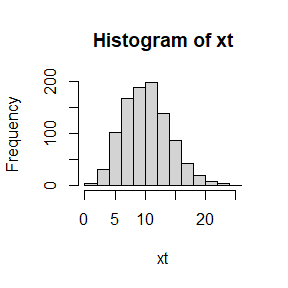

```r
r=2
beta=2
n=1000
t=10
nt=rpois(n,t)
xt=numeric(n)
i=j=0
for(i in 1:n){
  for(j in 1:nt[i]){
    xt[i]=xt[i]+rgamma(1,r,beta)
  }
}
hist(xt)
```

```r
m2=mean(xt)
v2=var(xt)
cat("the estimation of mean is ",m2,",the variance is ",v2,".the theoretical value of mean is 10,the variance is 15.")
```

```
## the estimation of mean is  10.26125 ,the variance is  15.46704 .the theoretical value of mean is 10,the variance is 15.
```

when r=4,$\beta=2$

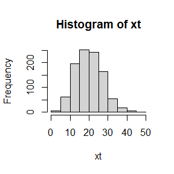

```r
r=4
beta=2
n=1000
t=10
nt=rpois(n,t)
xt=numeric(n)
i=j=0
for(i in 1:n){
  for(j in 1:nt[i]){
    xt[i]=xt[i]+rgamma(1,r,beta)
  }
}
hist(xt)
```

```r
m3=mean(xt)
v3=var(xt)
cat("the estimation of mean is ",m3,",the variance is ",v3,".the theoretical value of mean is 20,the variance is 50.")
```

```
## the estimation of mean is  20.02295 ,the variance is  50.89379 .the theoretical value of mean is 20,the variance is 50.
```

# Homework 2

1.Exercises 5.4, 5.9, and 5.13 (pages 149-151, Statistical Computing with R).

2.Monte Carlo experiment

- for n =$10^4,2\times10^4,4\times10^4,6\times10^4,8\times10^4$,apply the fast sorting algorithm to randomly permuted numbers of 1,…,n.
- Calculate computation time averaged over 100 simulations,denoted by $a_n$.
- Regress $a_n$ on $t_n:=nlog(n)$,and graphically show the results(scatter plot and regression line)

# Answer

## 5.4

**Question:**Write a function to compute a Monte Carlo estimate of the Beta(3,3) cdf,and use the function to estimate F(x) for x=0.1,0.2,…,0.9.Compare the estimates with the values returned by the pbeta function in R.

**Answer:** the pdf of Beta($\alpha$,$\beta$)is:

$$f(x)=\frac{\Gamma(\alpha+\beta)}{\Gamma(\alpha)\Gamma(\beta)}x^{\alpha-1}(1-x)^{\beta-1}$$

When the distribution is Beta(3,3),the pdf of Beta(3,3) is

$$f(x)=\frac{\Gamma(6)}{\Gamma(3)\Gamma(3)}x^2(1-x)^2=30x^2(1-x)^2$$

the cdf of Beta(3,3) is: $F(x)=\int_0^x30t^2(1-t)^2dt$

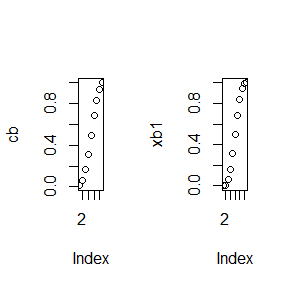

```r
MC_beta_cdf<-function(x,n){
  t<-runif(n,min=0,max=x)
  theta_hat<-mean(30*t^2*(1-t)^2)*x
  return(theta_hat)
}
cb<-numeric(0)
for(i in 1:9){
  cb[i]<-MC_beta_cdf(i/10,10000)
}
par(mfrow=c(1,2))
plot(cb)
xb1<-pbeta(seq(0,1,by=0.1),shape1=3,shape2=3)
plot(xb1)
```

The Monte Carlo methods fits well.

## 5.9

**Question:**The Rayleigh density is
$$f(x)=
\frac{x}{\sigma^2}e^{-\frac{x^2}{2\sigma^2}}$$
Implement a function to generate samples from a Rayleigh($\sigma$) distribution,using antithetic variables.What is the percent reduction in variance of (X+X’)/2 compared with (X1+X2)/2 for independent X1,X2?

**Answer:**

```r
MC.Phi <- function(x,sigma, R = 10000, antithetic = FALSE) {
  u <- runif(R/2)
  if (antithetic) v <- 1 - u else v <- runif(R/2)
  u <- c(u, v)
  g <- x*(u*x)*exp(-(u*x)^2/(2*sigma^2)) # x*u ~ N(0,x)
  cdf <- mean(g) / (sigma^2)
  cdf
}
m <- 1000
MC1 <- MC2 <- numeric(m)
x <- 1
for (i in 1:m) {
  MC1[i] <- MC.Phi(x,1, R = 1000, antithetic = FALSE)
  MC2[i] <- MC.Phi(x,1, R = 1000, antithetic = TRUE)
}
round(c(sd(MC1),sd(MC2),sd(MC2)/sd(MC1)),5)
```

```
## [1] 0.00569 0.00193 0.33939
```

## 5.13

**Question:**Find two importance functions $f_1$ and $f_2$ that are supported on (1,$\infty$) and ‘close’ to $g(x)=\frac{x^2}{\sqrt{2\pi}}e^{-x^2/2},x>1$. Which of your two importance functions should produce the smaller variance in estimating $\int_1^\infty \frac{x^2}{\sqrt{2\pi}}e^{-x^2/2}dx$ by importance sampling?Explain.

**Answer:**

when $f_1(x)=\frac{1}{\sqrt{2\pi}}e^{-1/x^2}$:

```r
n=10000
x1<-rnorm(n)
g<-function(x){
  x^2*exp(-x^2/2)/sqrt(2*pi)*(x>=1)
}
fg1<-g(x1)/dnorm(x1)
theta1<-mean(fg1)
sd1<-sd(fg1)
```

when$f_2(x)=e^{-x}$:

```r
x2<-rexp(n)
fg2<-g(x2)/exp(-x2)
theta2<-mean(fg2)
sd2<-sd(fg2)

theta<-c(theta1,theta2)
sd<-c(sd1,sd2)
res<-rbind(theta=round(theta,3),sd=round(sd,3))
res
```

```
##        [,1]  [,2]
## theta 0.405 0.402
## sd    1.144 0.586
```

Compare the sd of the two functions,we can find that $f_2(x)$ produce the smaller variance in estimating g(x) by importance sampling.

## Monte Carlo experiment

**Answer:**

fast sorting algorithm

```r
fsa<-function(x){  #fast sorting algorithm function
  if(length(x)<=1) {
    return(x)
  }
  p<-x[1]
  l<-x[x<p]
  r<-x[x>p]
  return(c(fsa(l),p,c(fsa(r))))
}
x1<-sample(1e4)
x2<-sample(2e4)
x3<-sample(4e4)
x4<-sample(6e4)
x5<-sample(8e4)

t1<-t2<-t3<-t4<-t5<-numeric(100)
for(i in 1:100){
  t1[i]<-system.time({fsa(x1)})[1]
  t2[i]<-system.time({fsa(x2)})[1]
  t3[i]<-system.time({fsa(x3)})[1]
  t4[i]<-system.time({fsa(x4)})[1]
  t5[i]<-system.time({fsa(x5)})[1]
}
t<-c(mean(t1),mean(t2),mean(t3),mean(t4),mean(t5))
```

```r
n<-c(1e4,2e4,4e4,6e4,8e4)
x0<-n*log(n)
model<-lm(t~x0)
r1<-model$coefficients[1]
r2<-model$coefficients[2]
```

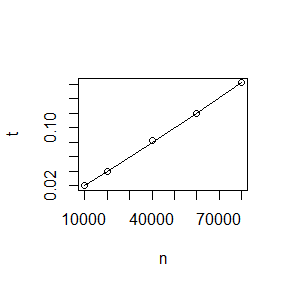

```r
plot(n,t)
lines(n,r1+r2*n*log(n))
```

the plot shows that the regression fits well.

# Homework 3

1.Exercise 6.6 and 6.B(page 180-181,Statistical Computing with R)

2.If we obtain the powers for two methods under a particular simulation setting with 10,000 experiment:say,0.651 for one method and 0.676 for another method.We want to know if the powers are different at 0.05 level.

(1)What is the corresponding hypothesis test problem?

(2)What test should we use?Z-test,two-sample t-test,paired-t test or McNemar test?Why?

(3)Please provide the least necessary information for hypothesis testing.

# Answer

## 6.6

**Question:** Estimate the 0.025,0.05,0.95,and 0.975 quantiles of the skewness $\sqrt{b_1}$ under normality by a Monte Carlo experiment.Compute the standard error of the estimates from (2.14) using the normal approximation for the density (with exact variance formula).Compare the estimated quantiles with the quantiles of the large sample approximation $\sqrt{b_1}\approx N(0,6/n)$.

**Answer:**

```r
skewness<-function(x){
  #compute the sample skewness statistics
  xbar<-mean(x)
  m1<-mean((x-xbar)^3)
  m2<-mean((x-xbar)^2)
  m3<-m1/m2^1.5
  return(m3)
}

eq<-function(x,q){
  #estimate the quantiles
  t<-quantile(x,q)
  return(t)
}

n=1e4
m=1e2
sk<-numeric(n)
for(i in 1:n){
  sk[i]<-skewness(rnorm(m))
}
```

```r
q<-eq(sk,c(0.025,0.05,0.95,0.975))
varq<-function(q){
  #compute the standard error
  f<-exp(-q^2/2)/sqrt(2*pi)
  r<-q*(1-q)/n/f^2
  return(r)
}
varq(q)
```

```
##          2.5%            5%           95%         97.5%
## -0.0005474696 -0.0004040686  0.0001721153  0.0001939267
```

```r
#compare the estimated quantiles with the quantiles of the large sample approximation sqrt(b_1) approx N(0,6/n)
com<-rnorm(n,sd=sqrt(6/m))
qcom<-eq(com,c(0.025,0.05,0.95,0.975))
result1<-function(q,qcom){
  #result reporting
  print(q)
  print(qcom)
}
result1(q,qcom)
```

```
##       2.5%         5%        95%      97.5%
## -0.4729704 -0.3946256  0.3835901  0.4645171
##       2.5%         5%        95%      97.5%
## -0.4755094 -0.4032506  0.4033278  0.4723740
```

We can find that $\sqrt{b_1}$ is asymptotically normal with mean 0 and variance 6/n.

## 6.B

**Question:**Tests for association based on Pearson product moment correlation $\rho$,Spearman’s rank correlation coefficient $\rho_s$,or Kendall’s coefficient $\tau$,are implemented in cor.test.Show (empirically) that the nonparametric tests based on $\rho_s$ or $\tau$ are less powerful than the correlation test when the sampled distribution is bivariate normal.Find an example of an alternative(a bivariate distribution(X,Y) such that X and Y are dependent) such that at least one of the nonparametric tests have better empirical power than the correlation test against this alternative.

**Answer:**

```r
library(MASS)
set.seed(12345)
data<-mvrnorm(10000,mu=c(0,0),Sigma=matrix(c(1,0,0,1),2,2))
cor.test(data[,1],data[,2],method=c("pearson"))
```

```
##
##  Pearson's product-moment correlation
##
## data:  data[, 1] and data[, 2]
## t = -1.5649, df = 9998, p-value = 0.1176
## alternative hypothesis: true correlation is not equal to 0
## 95 percent confidence interval:
##  -0.035238329  0.003952215
## sample estimates:
##         cor
## -0.01564907
```

```r
cor.test(data[,1],data[,2],method=c("spearman"))
```

```
##
##  Spearman's rank correlation rho
##
## data:  data[, 1] and data[, 2]
## S = 1.6884e+11, p-value = 0.1923
## alternative hypothesis: true rho is not equal to 0
## sample estimates:
##         rho
## -0.01304052
```

```r
cor.test(data[,1],data[,2],method=c("kendall"))
```

```
##
##  Kendall's rank correlation tau
##
## data:  data[, 1] and data[, 2]
## z = -1.302, p-value = 0.1929
## alternative hypothesis: true tau is not equal to 0
## sample estimates:
##          tau
## -0.008681348
```

A good test should have a power as large as possible,so the nonparametric tests based on $\rho_s$ or $\tau$ are less powerful than the correlation test when the sampled distribution is bivariate normal.

```r
x<-rexp(1000)
y<-rnorm(1000)
cor.test(x,y,method="pearson")
```

```
##
##  Pearson's product-moment correlation
##
## data:  x and y
## t = 0.806, df = 998, p-value = 0.4204
## alternative hypothesis: true correlation is not equal to 0
## 95 percent confidence interval:
##  -0.03654565  0.08736017
## sample estimates:
##        cor
## 0.02550522
```

```r
cor.test(x,y,method="spearman")
```

```
##
##  Spearman's rank correlation rho
##
## data:  x and y
## S = 162715202, p-value = 0.4539
## alternative hypothesis: true rho is not equal to 0
## sample estimates:
##        rho
## 0.02370781
```

```r
cor.test(x,y,method="kendall")
```

```
##
##  Kendall's rank correlation tau
##
## data:  x and y
## z = 0.72482, p-value = 0.4686
## alternative hypothesis: true tau is not equal to 0
## sample estimates:
##        tau
## 0.01530731
```

## 2

(1)Let the powers of the first and the second method are $p_1$ and $p_2$,so the corresponding hypothesis test problem is:
$$H_0:p_1=p_2 <->
H_1:p_1\neq p_2$$

(2)We can use paired-t test to solve this corresponding hypothesis problem.Because the data of two methods are paired,and n=10000 is large enough.

(3)The powers of the two methods are the least necessary information for hypothesis testing.Because when we use paired-t test,we just care about the difference between the two powers,and the specific value of powers is unnecessary.

# Homework 4

1.Of N=1000 hypotheses,950 are null and 50 are alternative.The p-value under any null hypothesis is uniformly distributed(use runif),and the p-value under any alternative hypothesis follows the beta distribution with parameter 0.1 and 1(use rbeta).Obtain Bonferroni adjusted p-values and B-H adjusted p-values.Calculate FWER,FDR,and TPR under nominal level $\alpha=0.1$ for each of the two adjustment methods based on m=10000 simulation replicates.You should output the 6 numbers(3) to a 3*2 table(column names:Bonferroni correction,B-H correction;row names:FWER,FDR,TPR).Comment the results. 2.Exercise 7.4-7.5(pages 232,Statistical Computating with R)

# Answer

## Question 1

```r
fwerbon<-fwerbh<-fdrbon<-fdrbh<-tprbon<-tprbh<-numeric(10000)
for(j in 1:10000){
  p0<-runif(950)
  p1<-rbeta(50,0.1,1)
  p<-sort(c(p0,p1))
  p.adj1<-p.adjust(p,method='bonferroni')
  p.adj2<-p.adjust(p,method='BH')
  fwer<-fdr<-tpr<-numeric(2)
  for(i in 1:1000){
    if(p.adj1[i]<0.1/1000) {fwer[1]<-fwer[1]+1}
    if(p.adj2[i]<0.1/1000) {fwer[2]<-fwer[2]+1}
    if(p.adj1[i]<0.1*i/1000) {fdr[1]<-fdr[1]+1}
    if(p.adj2[i]<0.1*i/1000) {fdr[2]<-fdr[2]+1}
  }
  fwerbon[j]<-fwer[1]/1000
  fwerbh[j]<-fwer[2]/1000
  fdrbon[j]<-fdr[1]/1000
  fdrbh[j]<-fdr[2]/1000
  tprbon[j]<-1-fdrbon[j]
  tprbh[j]<-1-fdrbh[j]
}
```

```r
r<-matrix(c(mean(fwerbon),mean(fwerbh),mean(fdrbon),mean(fdrbh),mean(tprbon),mean(tprbh)),byrow=TRUE,nrow=3)
colnames(r)<-c('bonferroni','BH')
rownames(r)<-c('FWER','FDR','TPR')
round(r,4)
```

```
##      bonferroni     BH
## FWER      0.010 0.0130
## FDR       0.013 0.0179
## TPR       0.987 0.9821
```

When using the Bonferroni adjusted p-values and B-H adjusted p-values,the family wise error rate and false discovery rate are very low and close,and the true discovery rate is very high.

## 7.4

**Question:**Refer to the air-conditioning data set aircondit provided in the boot package.The 12 observations are the times in hours between failures of air-conditioning equipment: 3,5,7,18,43,85,91,98,100,130,230,487. Assume that the times between failures follow an exponential model EXP($\lambda$).Obtain the MLE of the hazard rate $\lambda$ and use bootstrap to estimate the bias and standard error of the estimate.

**Answer:**

The MLE of the hazard rate $\lambda$ is $1/\bar{X}$

```r
# compute the MLE of lambda_hat
library(boot)
f<-function(lambda){
  return(length(x)*log(lambda)-lambda*sum(x))
}
x<-c(3, 5, 7, 18, 43, 85, 91, 98, 100, 130, 230, 487)
optimize(f,interval=c(0,2),maximum = TRUE)
```

```
## $maximum
## [1] 0.009245542
##
## $objective
## [1] -68.19483
```

```r
#Bootstrap method
B=1e4
set.seed(12345)
lambdastar<-numeric(B)
lambda1<-1/mean(x)
for(i in 1:B){
  xstar<-sample(x,replace=TRUE)
  lambdastar[i]<-1/mean(xstar)
}
round(c(bias=mean(lambdastar)-lambda1,se.boot=sd(lambdastar)),5)
```

```
##    bias se.boot
## 0.00132 0.00429
```

# 7.5

**Question:**Refer to Exercise 7.4,Compute 95% bootstrap confidence intervals for the mean time between failures $1/\lambda$ by the standard normal,basic,percentile,and BCa methods.Compare the intervals and explain why they may differ.

**Answer:**

```r
#basic method
fb<-function(x,i){return(mean(x[i]))}
bx<-boot(data=x,statistic=fb,R=999)
ci<-boot.ci(bx,type=c("norm","basic","perc","bca"))
ci
```

```
## BOOTSTRAP CONFIDENCE INTERVAL CALCULATIONS
## Based on 999 bootstrap replicates
##
## CALL :
## boot.ci(boot.out = bx, type = c("norm", "basic", "perc", "bca"))
##
## Intervals :
## Level      Normal              Basic
## 95%   ( 30.7, 182.2 )   ( 22.7, 168.7 )
##
## Level     Percentile            BCa
## 95%   ( 47.5, 193.5 )   ( 56.5, 231.8 )
## Calculations and Intervals on Original Scale
## Some BCa intervals may be unstable
```

# Question

Exercises 7.8,7.10,8.1 and 8.2(pages 213 and 243,Statistical Computing with R)

# Answer

## 7.8

**Question:** Refer to Exercise 7.7,Obtain the jackknife estimates of bias and standard error of $\hat{\theta}$.

**Answer:**

```r
library(bootstrap)
data1<-scor
dc<-cov(data1)
f1<-function(dc){
  #compute the theta
  l<-eigen(dc,only.values = TRUE)$values
  theta<-l[1]/sum(l)
  return(theta)
}
theta<-f1(dc)
```

```r
n<-dim(data1)[1]
thetahat<-numeric(n)
f2<-function(data1){
  #jackknife
  for(i in 1:n){
    data2<-data1[-i]
    c<-cov(data2)
    thetahat[i]<-f1(c)
  }
  return(thetahat)
}
thetahat<-f2(data1)
bias.jack<-(n-1)*(mean(thetahat)-theta)
se.jack<-sqrt((n-1)*mean((thetahat-theta)^2))


f3<-function(theta,bias.jack,se.jack){
  #show the result
  round(c(original=theta,bias.jack=bias.jack,se.jack=se.jack),3)
}
f3(theta,bias.jack,se.jack)
```

```
##  original bias.jack   se.jack
##     0.619     0.151     0.090
```

```r
rm(list=ls())
```

## 7.10

**Question:** In Example 7.18,leave-one-out(n-fold) cross validation was used to select the best fitting model.Repeat the analysis replacing the Log-Log model with a cubic polynomial model.Which of the four models is selected by the cross validation procedure?Which model is selected according the maximum adjusted $R^2$?

**Answer:**

```r
library(DAAG)
attach(ironslag)
n <- length(magnetic)
e1 <- e2 <- e3 <- e4 <- numeric(n)
# for n-fold cross validation
# fit models on leave-one-out samples
for (k in 1:n) {
  y <- magnetic[-k]
  x <- chemical[-k]
  J1 <- lm(y ~ x)
  yhat1 <- J1$coef[1] + J1$coef[2] * chemical[k]
  e1[k] <- magnetic[k] - yhat1

  J2 <- lm(y ~ x + I(x^2))
  yhat2 <- J2$coef[1] + J2$coef[2] * chemical[k] +
  J2$coef[3] * chemical[k]^2
  e2[k] <- magnetic[k] - yhat2

  J3 <- lm(log(y) ~ x)
  logyhat3 <- J3$coef[1] + J3$coef[2] * chemical[k]
  yhat3 <- exp(logyhat3)
  e3[k] <- magnetic[k] - yhat3

  J4 <- lm(y ~ x + I(x^2) + I(x^3))
  yhat4 <- J4$coef[1] + J4$coef[2] * chemical[k] +
  J4$coef[3] * chemical[k]^2 + J4$coef[4]*chemical[k]^3
  e4[k] <- magnetic[k] - yhat4
}
c(mean(e1^2),mean(e2^2),mean(e3^2),mean(e4^2))
```

```
## [1] 19.55644 17.85248 18.44188 18.17756
```

According to the prediction error criterion,Model 2,the quadratic model,would be the best fit for the data.

```r
summary(J1)
```

```
##
## Call:
## lm(formula = y ~ x)
##
## Residuals:
##     Min      1Q  Median      3Q     Max
## -9.5784 -2.3022 -0.0203  2.1964 11.9740
##
## Coefficients:
##             Estimate Std. Error t value Pr(>|t|)
## (Intercept)   1.7881     2.5077   0.713    0.479
## x             0.8895     0.1159   7.678 5.25e-10 ***
## ---
## Signif. codes:  0 '***' 0.001 '**' 0.01 '*' 0.05 '.' 0.1 ' ' 1
##
## Residual standard error: 4.188 on 50 degrees of freedom
## Multiple R-squared:  0.5411, Adjusted R-squared:  0.5319
## F-statistic: 58.95 on 1 and 50 DF,  p-value: 5.249e-10
```

```r
summary(J2)
```

```
##
## Call:
## lm(formula = y ~ x + I(x^2))
##
## Residuals:
##     Min      1Q  Median      3Q     Max
## -8.2243 -2.4454 -0.1374  2.2346 12.5821
##
## Coefficients:
##             Estimate Std. Error t value Pr(>|t|)
## (Intercept) 25.98525    8.75932   2.967  0.00464 **
## x           -1.52948    0.85065  -1.798  0.07834 .
## I(x^2)       0.05707    0.01991   2.867  0.00609 **
## ---
## Signif. codes:  0 '***' 0.001 '**' 0.01 '*' 0.05 '.' 0.1 ' ' 1
##
## Residual standard error: 3.915 on 49 degrees of freedom
## Multiple R-squared:  0.607,  Adjusted R-squared:  0.591
## F-statistic: 37.84 on 2 and 49 DF,  p-value: 1.154e-10
```

```r
summary(J3)
```

```
##
## Call:
## lm(formula = log(y) ~ x)
##
## Residuals:
##      Min       1Q   Median       3Q      Max
## -0.63621 -0.08603 -0.00391  0.10665  0.44188
##
## Coefficients:
##             Estimate Std. Error t value Pr(>|t|)
## (Intercept) 2.127402   0.115186  18.469  < 2e-16 ***
## x           0.040570   0.005321   7.624 6.37e-10 ***
## ---
## Signif. codes:  0 '***' 0.001 '**' 0.01 '*' 0.05 '.' 0.1 ' ' 1
##
## Residual standard error: 0.1924 on 50 degrees of freedom
## Multiple R-squared:  0.5376, Adjusted R-squared:  0.5283
## F-statistic: 58.13 on 1 and 50 DF,  p-value: 6.371e-10
```

```r
summary(J4)
```

```
##
## Call:
## lm(formula = y ~ x + I(x^2) + I(x^3))
##
## Residuals:
##     Min      1Q  Median      3Q     Max
## -8.4347 -2.0627 -0.3247  2.2127 13.1177
##
## Coefficients:
##              Estimate Std. Error t value Pr(>|t|)
## (Intercept) -2.763718  26.402670  -0.105    0.917
## x            2.908468   3.938834   0.738    0.464
## I(x^2)      -0.160916   0.189976  -0.847    0.401
## I(x^3)       0.003424   0.002968   1.154    0.254
##
## Residual standard error: 3.902 on 48 degrees of freedom
## Multiple R-squared:  0.6176, Adjusted R-squared:  0.5937
## F-statistic: 25.84 on 3 and 48 DF,  p-value: 4.264e-10
```

Model 4 is selected according the maximum adjusted $R^2$.

```r
rm(list=ls())
```

## 8.1

**Question:** Implement the two-sample Cramer-von Mises test for equal distributions as a permutation test.Apply the test to the data in Example 8.1 and 8.2. **Answer:**

```r
attach(chickwts)
x <- sort(as.vector(weight[feed == "soybean"]))
y <- sort(as.vector(weight[feed == "linseed"]))
detach(chickwts)
```

```r
library(twosamples) #call the function cvm_test
R <- 999 #number of replicates
z <- c(x, y) #pooled sample
K <- 1:26
options(warn = -1)
D0 <- cvm_test(x, y)[2]

cvm<-function(){
  D<-numeric(R)
  for (i in 1:R) {
    #generate indices k for the first sample
    k <- sample(K, size = 14, replace = FALSE)
    x1 <- z[k]
    y1 <- z[-k]
    D[i] <- cvm_test(x1, y1)[2]
  }
  return(D)
}
D<-cvm()
cp<-function(D0,D){
  p <- mean(c(D0, D) >= D0)
  return(p)
}
p<-cp(D0,D)
options(warn = 0)
p
```

```
## [1] 0.584
```

When using the two-sample Cramer-von Mises test,the approximate ASL does not support the alternative hypothesis that distributions differ.

```r
rm(list=ls())
```

## 8.2

**Question:** Implement the bivariate Spearman rank correlation test for independence as a permutation test.The Spearman rank correlation test statistic can be obtained from function cor with method=“spearman”.Compare the achieved significance level of the permutation test with the p-value reported by cor.test on the same samples.

**Answer:**

```r
attach(chickwts)
x <- sort(as.vector(weight[feed == "sunflower"]))
y <- sort(as.vector(weight[feed == "linseed"]))
detach(chickwts)
```

```r
R<-999
z<-c(x,y)
K<-1:24
options(warn=-1)
D0<-cor(x,y,method="spearman")

spearman<-function(){
  D<-numeric(R)
  for (i in 1:R) {
    k <- sample(K, size = 12, replace = FALSE)
    x1 <- z[k]
    y1 <- z[-k]
    D[i] <- cor(x1,y1,method="spearman")
  }
  return(D)
}
D<-spearman()

sp<-function(D0,D){
  p <- mean(c(D0, D) >= D0)
  return(p)
}
p<-sp(D0,D)
options(warn = 0)

r<-function(p){
  if(p<=0.05){print("reject the null hypothesis")}
  else {print("accept the null hypothesis")}
}
r(p)
```

```
## [1] "reject the null hypothesis"
```

```r
cp<-cor.test(x,y)[3]
r(cp)
```

```
## [1] "reject the null hypothesis"
```

The result of the two test is the same:reject the null hypothesis.

```r
rm(list=ls())
```

# Question:

1.Exercies 9.3 and 9.8 (pages 277-278, Statistical Computing with R). 2.For each of the above exercise, use the Gelman-Rubin method to monitor convergence of the chain, and run the chain until it converges approximately to the target distribution according to $\hat{R}$ < 1.2.

# Answer:

## 9.3

**Question:**

Use the Metropolis-Hastings sampler to generate random variables from a standard Cauchy distribution. Discard the first 1000 of the chain, and compare the deciles of the generated observations with the deciles of the standard Cauchy distribution (see qcauchy or qt with df=1). Recall that a Cauchy(θ, η) distribution has density function
$$f(x)=\frac{1}{\theta\pi(1+[(x-\eta)/\theta]^2)}$$
The standard Cauchy has the Cauchy(θ = 1, η = 0) density. (Note that the standard Cauchy density is equal to the Student t density with one degree of freedom.)

**Answer:**

```r
fc<-function(x,eta,theta){
  return(1/(theta*pi*(1+((x-eta)/theta)^2)))
}

MH<-function(){
  m<-10000
  eta<-0
  theta<-1
  x<-numeric(m)
  x[1]<-rnorm(1,1)
  u<-runif(m)

  for(i in 2:m){
    xt<-x[i-1]
    y<-rnorm(1,xt)
    num<-fc(y,eta,theta)*dnorm(xt,y)
    den<-fc(xt,eta,theta)*dnorm(y,xt)
    if(u[i] <= num/den){
      x[i]<-y
    }
    else{
      x[i]<-xt
    }
  }
  return(x)
}
```

```r
q<-c(10,20,30,40,50,60,70,80,90)/100
x<-MH()[1001:10000]
nc<-rcauchy(9000)
m1<-quantile(x,q,na.rm=TRUE)
m2<-quantile(nc,q)

r<-function(m1,m2){
  print("the deciles of the generated observations is ")
  print(m1)
  print("the deciles of the standard Cauchy distribution is ")
  print(m2)
}
r(m1,m2)
```

```
## [1] "the deciles of the generated observations is "
##        10%        20%        30%        40%        50%        60%        70%
## -1.9069266 -0.9475918 -0.4812827 -0.1280205  0.1787377  0.5518450  1.0631548
##        80%        90%
##  1.9663760  5.3215236
## [1] "the deciles of the standard Cauchy distribution is "
##        10%        20%        30%        40%        50%        60%        70%
## -2.8809623 -1.3264050 -0.6917426 -0.2940965  0.0279795  0.3568793  0.7625503
##        80%        90%
##  1.4132234  3.0834378
```

```r
Gelman.Rubin <- function(psi) {
  psi <- as.matrix(psi)
  n <- ncol(psi)
  k <- nrow(psi)
  psi.means <- rowMeans(psi) #row means
  B <- n * var(psi.means) #between variance est.
  psi.w <- apply(psi, 1, "var") #within variances
  W <- mean(psi.w) #within est.
  v.hat <- W*(n-1)/n + (B/n) #upper variance est.
  r.hat <- v.hat / W #G-R statistic
  return(r.hat)
}
```

```r
n=9000

#generate the chains
for(k in 2:10){
  X <- matrix(0, nrow=k, ncol=n)
  for (i in 1:k){
    X[i, ] <- MH()[1001:10000]
  }

#Compute the diagnostic statistics
  psi <- t(apply(X, 1, cumsum))
  for (i in 1:nrow(psi)){
    psi[i,] <- psi[i,] / (1:ncol(psi))
  }
  if(Gelman.Rubin(psi)<1.2) break
}
print(c(Gelman.Rubin(psi),k))
```

```
## [1] 1.036273 3.000000
```

```r
rm(list=ls())
```

## 9.8

**Question:**

This example appears in [40]. Consider the bivariate density
$$f(x,y)\propto C_n^x
y^{x+a-1}(1-y)^{n-x+b-1},x=0,1,...,n,0 \leq y \leq 1$$
It can be shown (see e.g. [23]) that for fixed a, b, n, the conditional distributions are Binomial(n, y) and Beta(x + a, n − x + b). Use the Gibbs sampler to generate a chain with target joint density f(x, y).

**Answer:**

```r
N=5000
burn=1000
a=b=1
n=100
Gibbs<-function(){
  X<-matrix(0,N,2)

  y<-0.5
  x<-50
  X[1,]<-c(x,y)

  for(i in 2:N){
    x2<-X[i-1,2]
    X[i,1]<-rbinom(1,100,x2)
    x1<-X[i-1,1]
    X[i,2]<-rbeta(1,x1+a,n-x1+b)
  }
  b<-burn+1
  x<-X[b:N,]
  return(x)
}

fcom<-function(x,n){
  return(factorial(x)*factorial(n-x)/factorial(n))
}

fd<-function(x,y){
  #density f(x,y)
  return(fcom(x,n)*(y^(x+a-1))*((1-y)^(n-x+b-1)))
}

x<-Gibbs()
result<-fd(x[,1],x[,2])
```

```r
Gelman.Rubin <- function(psi) {
  psi <- as.matrix(psi)
  n <- ncol(psi)
  k <- nrow(psi)
  psi.means <- rowMeans(psi) #row means
  B <- n * var(psi.means) #between variance est.
  psi.w <- apply(psi, 1, "var") #within variances
  W <- mean(psi.w) #within est.
  v.hat <- W*(n-1)/n + (B/n) #upper variance est.
  r.hat <- v.hat / W #G-R statistic
  return(r.hat)
}
```

```r
n=4000

#generate the chains
for(k in 2:10){
  X1 <- matrix(0, nrow=k, ncol=n)
  X2 <- matrix(0, nrow=k, ncol=n)
  for (i in 1:k){
    X1[i, ] <- Gibbs()[,1]
    X2[i, ] <- Gibbs()[,2]
  }

#Compute the diagnostic statistics
  psi1 <- t(apply(X1, 1, cumsum))
  for (i in 1:nrow(psi1)){
    psi1[i,] <- psi1[i,] / (1:ncol(psi1))
  }
  psi2 <- t(apply(X2, 1, cumsum))
  for (i in 1:nrow(psi2)){
    psi2[i,] <- psi2[i,] / (1:ncol(psi2))
  }
  if(Gelman.Rubin(psi1)<1.2&Gelman.Rubin(psi2)<1.2) break
}
print(c(Gelman.Rubin(psi1),Gelman.Rubin(psi2)<1.2,k))
```

```
## [1]  1.227668  0.000000 10.000000
```

```r
rm(list=ls())
```

# Homework 7

1.Exercises 11.3 and 11.5 (pages 353-354, Statistical Computing with R)

2.Suppose $T_1,...,T_n$ are i.i.d. samples drawn fron the exponential distribution with expectation $\lambda$. Those values greater than $\tau$ are not observed due to right censorship,so that the observed values are $Y_i=T_iI(T_i\leq \tau)+\tau I(T_i > \tau)$, i=1,…,n. Suppose $\tau=1$ and the observed $Y_i$ values are as follows: 0.54,0.48,0.33,0.43,1.00,1.00,0.91,1.00,0.21,0.85 Use the E-M algorithm to estimate $\lambda$,compare your result with the observed data MLE(note:$Y_i$ follows a mixture distribution).

# Answer

## 11.3

```r
an<-function(a){
  #Euclidean norm
  return(sqrt(sum(a^2)))
}

lf<-function(n){
  #log factorial function
  if(n==0){
    return(0)
  }else{
    return(log(n)+lf(n-1))
  }
}

kt<-function(a,k,d){
  #k_th term
  lterm<-log(an(a))+lgamma((d+1)/2)+lgamma(k+3/2)-lf(k)-k*log(2)-log(2*k+1)-log(2*k+2)-lgamma(k+d/2+1)
  return((-1)^k*exp(lterm))
}
```

```r
fsum<-function(a,k,d){
  f<-0
  for(i in 0:k){
    f<-f+kt(a,i,d)
  }
  return(f)
}
```

```r
a<-c(1,2)
k<-2000
d<-2
fsum(a,k,d)
```

```
## [1] 0.8274602
```

```r
rm(list=ls())
```

## 11.5

```r
ck<-function(a,k){
  return(sqrt((a^2)*k/(k+1-a^2)))
}

f<-function(a){
  pt(ck(a,k),df=k)-pt(ck(a,k-1),df=k-1)
}
```

```r
fa<-function(k){
  res<-uniroot(f,c(0.1,sqrt(k)-0.1))
  return(res$root)
}

a<-numeric(22)
for(k in 4:25){
  a[k-3]<-fa(k)
}
names(a)<-4:25
print(a)
```

```
##        4        5        6        7        8        9       10       11
## 1.492103 1.533582 1.562744 1.584429 1.601183 1.614536 1.625366 1.634415
##       12       13       14       15       16       17       18       19
## 1.642017 1.648547 1.654170 1.659098 1.663444 1.667283 1.670738 1.673795
##       20       21       22       23       24       25
## 1.676614 1.679154 1.681472 1.683594 1.685569 1.687336
```

a is equal to the solutions with the point A(k).

```r
rm(list=ls())
```

## 2

```r
T0<-c(0.54,0.48,0.33,0.43,1.00,1.00,0.91,1.00,0.21,0.85)

MLE<-function(T0){
  return(length(T0)/sum(T0))
}

lambda0<-lambda<-MLE(T0)
that<-1+1/lambda
T0[T0==1.00]<-that


N=10000
tol<-.Machine$double.eps^0.5
for(i in 1:N){
  t<-lambda
  lambda<-MLE(T0)
  that<-1+1/lambda
  T0[T0==t]<-that
  if(abs(lambda-t)/t<tol) break
}

round(c(MLE=lambda0,EM=lambda),4)
```

```
##    MLE     EM
## 1.4815 1.1396
```

```r
rm(list=ls())
```

# Homework 8

1.Exercises 11.7 (page 354, Statistical Computing with R)

2.Exercises 3, 4, 5 (page 204, Advanced R)

3.Excecises 3 and 6 (page 213-214, Advanced R)

4.Excecise4 4-5 (page 365, Advanced R)

# Answer

```r
library(boot)
A1<-rbind(c(2,1,1),c(1,-1,3))
b1<-c(1,3)
a<-c(4,2,9)
simplex(a=a,A1=A1,b1=b1,maxi=FALSE)
```

```
##
## Linear Programming Results
##
## Call : simplex(a = a, A1 = A1, b1 = b1, maxi = FALSE)
##
## Minimization Problem with Objective Function Coefficients
## x1 x2 x3
##  4  2  9
##
##
## Optimal solution has the following values
## x1 x2 x3
##  0  0  0
## The optimal value of the objective  function is 0.
```

```r
rm(list=ls())
```

p204 3

```r
formulas <- list(
    mpg ~ disp,
    mpg ~ I(1 / disp),
    mpg ~ disp + wt,
    mpg ~ I(1 / disp) + wt
)

mod1<-lapply(formulas,function(x){lm(x,data=mtcars)})
```

p204 4

```r
bootstraps <- lapply(1:10, function(i) {
  rows <- sample(1:nrow(mtcars), rep = TRUE)
  mtcars[rows, ]
})

formulas<-list(y~x)
mod2<-list()  #save the result
for(i in seq_along(bootstraps)){
  y<-bootstraps[[i]]$mpg
  x<-bootstraps[[i]]$disp
  mod2<-append(mod2,lapply(formulas,lm))
}
```

p204 5

```r
rsq <- function(mod) summary(mod)$r.squared

rsq1<-numeric(4)
rsq2<-numeric(10)

for(i in 1:4){
  rsq1[i]<-rsq(mod1[[i]])
}

for(i in 1:10){
  rsq2[i]<-rsq(mod2[[i]])
}

round(c(rsq1=rsq1),3)
```

```
## rsq11 rsq12 rsq13 rsq14
## 0.718 0.860 0.781 0.884
```

```r
round(c(rsq2=rsq2),3)
```

```
##  rsq21  rsq22  rsq23  rsq24  rsq25  rsq26  rsq27  rsq28  rsq29 rsq210
##  0.716  0.603  0.718  0.656  0.744  0.785  0.794  0.812  0.628  0.823
```

```r
rm(list=ls())
```

p213 3

```r
trials <- replicate(
  100,
  t.test(rpois(10, 10), rpois(7, 10)),
  simplify = FALSE
)

pv1<-sapply(trials,function(x) x$p.value)

pv2<-numeric(100)
for(i in 1:100){
  pv2[i]<-trials[[i]]$p.value
}
round(pv1,3)
```

```
##   [1] 0.214 0.943 0.489 0.247 0.736 0.179 0.096 0.209 0.464 0.315 0.417 0.721
##  [13] 0.981 0.472 0.963 0.184 0.487 0.075 0.806 0.343 0.747 0.634 0.994 0.160
##  [25] 0.806 0.461 0.967 0.731 0.027 0.575 0.604 0.286 0.866 0.940 0.762 0.470
##  [37] 0.602 0.934 0.608 0.468 0.360 0.141 0.233 0.604 0.756 0.049 0.954 0.447
##  [49] 0.404 0.121 0.452 0.744 0.293 0.101 0.796 0.488 0.461 0.667 0.808 0.876
##  [61] 0.081 0.581 0.905 0.918 0.333 0.871 0.307 0.579 0.904 0.575 0.719 0.059
##  [73] 0.041 0.322 0.491 0.444 0.234 0.035 0.605 0.198 0.297 0.900 0.581 0.543
##  [85] 0.957 0.355 0.189 0.011 0.825 0.413 0.602 0.915 0.603 0.297 0.672 0.833
##  [97] 0.747 0.008 0.926 0.180
```

```r
round(pv2,3)
```

```
##   [1] 0.214 0.943 0.489 0.247 0.736 0.179 0.096 0.209 0.464 0.315 0.417 0.721
##  [13] 0.981 0.472 0.963 0.184 0.487 0.075 0.806 0.343 0.747 0.634 0.994 0.160
##  [25] 0.806 0.461 0.967 0.731 0.027 0.575 0.604 0.286 0.866 0.940 0.762 0.470
##  [37] 0.602 0.934 0.608 0.468 0.360 0.141 0.233 0.604 0.756 0.049 0.954 0.447
##  [49] 0.404 0.121 0.452 0.744 0.293 0.101 0.796 0.488 0.461 0.667 0.808 0.876
##  [61] 0.081 0.581 0.905 0.918 0.333 0.871 0.307 0.579 0.904 0.575 0.719 0.059
##  [73] 0.041 0.322 0.491 0.444 0.234 0.035 0.605 0.198 0.297 0.900 0.581 0.543
##  [85] 0.957 0.355 0.189 0.011 0.825 0.413 0.602 0.915 0.603 0.297 0.672 0.833
##  [97] 0.747 0.008 0.926 0.180
```

p214 6

```r
lapply1<-function(x,fun,fun.value){
  rv<-vapply(x,FUN = fun,FUN.VALUE = fun.value)
  Map(as.matrix,rv)
}

x<-data.frame(cbind(x1=c(1,2,3,4),x2=c(5,6,7,8)))
result<-lapply1(x,mean,numeric(1))
result
```

```
## $x1
##      [,1]
## [1,]  2.5
##
## $x2
##      [,1]
## [1,]  6.5
```

```r
rm(list=ls())
```

p365 4

```r
fastchisq.test<-function(x,y){
  if(is.numeric(x)&&is.numeric(y)){
    if(any(is.na(x)|is.na(y))) print("the vectors have missing values")
    else return(chisq.test(x,y))
  }
  else print("not numeric vectors")
}

#example
x<-c(1,2,2,1)
y<-c(1,1,1,2)
fastchisq.test(x,y)
```

```
##
##  Pearson's Chi-squared test with Yates' continuity correction
##
## data:  x and y
## X-squared = 0, df = 1, p-value = 1
```

```r
x<-c(1,2,2,1)
y<-c(1,2,2,NA)
fastchisq.test(x,y)
```

```
## [1] "the vectors have missing values"
```

```r
x<-c(1,2,2,1)
y<-c(1,2,2,"a")
fastchisq.test(x,y)
```

```
## [1] "not numeric vectors"
```

```r
rm(list=ls())
```

p365 5

```r
ftable<-function(x,y){
  if(!is.integer(x)||!is.integer(y)||any(is.na(x)|is.na(y))){
    print("error")
  }else{
    table(x,y)
  }
}

#example
x<-as.integer(c(1,2,3))
y<-as.integer(c(3,1,2))
ftable(x,y)
```

```
##    y
## x   1 2 3
##   1 0 0 1
##   2 1 0 0
##   3 0 1 0
```

```r
x<-c(0.1,2,3)
y<-c(3,1,0.2)
ftable(x,y)
```

```
## [1] "error"
```

```r
rm(list=ls())
```

# Question

Write an Rcpp function for Exercise 9.8 (page 278, Statistical Computing with R).

Compare the corresponding generated random numbers with those by the R function you wrote using the function “qqplot”.

Compare the computation time of the two functions with the function “microbenchmark”.

Comments your results.

# Answer

```r
library(Rcpp)
dir_cpp<-'D:/a/'
sourceCpp(paste0(dir_cpp,"Gibbs.cpp"))
N <- 5000
burn <- 1000
a <- 1
b <- 1
n <- 100


result <- Gibbs(N, burn, n, a, b)
result<-result[1001:5000,]

fcom<-function(x,n){
  return(factorial(x)*factorial(n-x)/factorial(n))
}

fd<-function(x,y){
  #density f(x,y)
  return(fcom(x,n)*(y^(x+a-1))*((1-y)^(n-x+b-1)))
}

fcpp<-fd(result[,1],result[,2])
```

```r
Gibbsr<-function(){
  X<-matrix(0,N,2)

  y<-0.5
  x<-50
  X[1,]<-c(x,y)

  for(i in 2:N){
    x2<-X[i-1,2]
    X[i,1]<-rbinom(1,100,x2)
    x1<-X[i-1,1]
    X[i,2]<-rbeta(1,x1+a,n-x1+b)
  }
  b<-burn+1
  x<-X[b:N,]
  return(x)
}

x<-Gibbsr()
fr<-fd(x[,1],x[,2])
```

Considering that the obtained data values are relatively small, take the logarithm to create a QQ chart

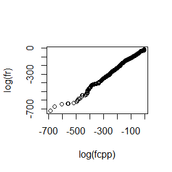

```r
qqplot(log(fcpp),log(fr))
```

```r
library(microbenchmark)
ts<-microbenchmark(timecpp=Gibbs(N, burn, n, a, b),timer=Gibbsr())
summary(ts)[,c(1,3,5,6)]
```

```
##      expr        lq    median        uq
## 1 timecpp  2.395401  2.430801  2.536151
## 2   timer 24.487651 26.267451 28.993550
```

Rcpp is faster and more efficient in solving the 9.8 problem compared to R.